# Generate stable network topos

longxiao

This R Notebook introduces the methods to generate stable initial networks.

```r
library(ggplot2)
library(patchwork)
#"nortest", "moments"
```

# Model

In the gene regulatory network system, a general model is:

$$s_{i}(t+1) = \sigma \left( \sum w_{ij} s_{j}(t) \right)$$

where $s_{i}(t)$ is the expression of gene $i$ at $t$, $w_{ij}$ is the regulation strength, $\sigma$ is some functions to constraint the system. For example, let us take

$$\sigma(x) =
\begin{cases}
x_{max} & x\geq x_{max}\\
x & x_{min}<x<x_{max}\\
x_{min} & x \leq x_{min}
\end{cases}$$

to limit the expression in the boundary $(s_{min}, s_{max})$.

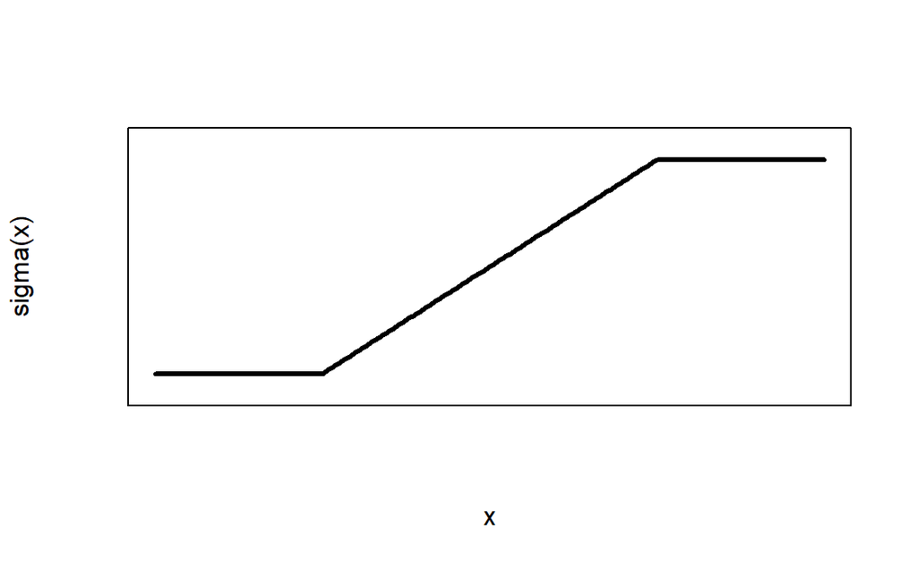

We assume that a real gene regulatory system would have a stable equilibrium. Without any disturb and noise, the expressions will converge to the equilibrium, making a relatively stable inner environment.

The former $\sigma(\cdot)$ only affect the system when gene expression value is too large or small. When all the expressions are in the linear region,

$$\mathbf{s}_{t+1} = \mathbf{W} \cdot \mathbf{s}_{t}$$

even if here is a stable equilibrium, the equilibrium could only be $\mathbf{0}_{n}$.

**Explanation**

Let $\mathbf{W} = \mathbf{V} \mathbf{\Lambda}\mathbf{V}^{-1}$ (where $\mathbf{\Lambda} = diag\{\lambda_1, \lambda_2, ... \lambda_{i}... \lambda_{n} \}$, $\mathbf{V} = diag\{v_1, v_2, ... v_{i}... v_{n} \}$,), when there is a stable equilibrium, it satisfies $\max |\lambda_i(\mathbf{W})|<1$. Thus $\lim_{t \rightarrow \infty}\mathbf{\Lambda}^{t} = 0$, then we have:
$$s_{t} = \mathbf{W}^{t}s_{0} = \mathbf{V} \mathbf{\Lambda}^{t}
\mathbf{V}^{-} s_{0} =0$$

However, we hope the system has at least one non-zero stable point, which represent the fittest phenotype. To fulfill this condition, we sould consider a little bit more complex system.

We add an constant to the system, as the basal expression:

$$\mathbf{s}(t+1) = \mathbf{W} \cdot \mathbf{s}(t) + \mathbf{b}$$

Same to the linear system, we still have $\mathbf{u}(t+1) = \mathbf{W} \cdot \mathbf{u}(t)$. As a result, the stable condition is the same, $\max |\lambda_i(\mathbf{W})|<1$. Besides, because of the shift $\mathbf{b}$, there is possible non-zero stable points.

Considering a equilibrium $\mathbf{s}^*$,

$$\mathbf{s}^* = \mathbf{W} \cdot \mathbf{s}^* + \mathbf{b}$$

$$(\mathbf{I} - \mathbf{W}) \cdot \mathbf{s}^* = \mathbf{b}$$

When $\mathbf{I} - \mathbf{W}$ is reversible,

$$\mathbf{s}^* = \mathbf{b} \cdot (\mathbf{I} - \mathbf{W})^{-1}$$

In our case, we assume the expression is normalized, as a result, we could set $\mathbf{s}^* = a \cdot \mathbf{1}_{n}$ as the fittest expression. And to simplify the system, we also assume $\mathbf{b} = b \cdot \mathbf{1}_{n}$. As a result, we need $\mathbf{W}$ also fulfills:

$$\mathbf{s}^* = \mathbf{W} \cdot \mathbf{s}^* + \mathbf{b}\\
a \cdot \mathbf{1}_{n} = \mathbf{W} \cdot a \cdot \mathbf{1}_{n} + b
\cdot \mathbf{1}_{n}\\
\frac{a-b}{a} \cdot \mathbf{1}_{n} = \mathbf{W} \cdot \mathbf{1}_{n}$$

which means that $\mathbf{W}$ has an eigenvalue $\frac{a-b}{a}$, and corresponding eigenvector is $\mathbf{1}_{n}$. Remember all of the eigenvalues should no longer than $1$. As a result, $-1<\frac{a-b}{a}<1$, which is $0<b<2a$.

Now we get the two conditions that a stable initial network should follows:

- $\max |\lambda_i(\mathbf{W})|<1$
- $\frac{a-b}{a} \cdot \mathbf{1}_{n} = \mathbf{W} \cdot \mathbf{1}_{n}$

We aim to generate some “random” matrices that have a stable equilibrium, as the initial population of further simulations. Furthermore, we hope these equilibrium could be around the same stable point (as the result of normalization for each gene).

# Methods

As we already know, a random large matrix (size 20 is enough to say so) is less probable to be stable. Thus, it would be inefficient or even impossible to generate matrices fulfills above conditions by check randomly generated matrices. Since these two conditions are both about eigenvalues and eigenvectors, we considering to generate $\mathbf{W}$ by diagnolization:

$$\mathbf{W} = \mathbf{V} \mathbf{\Lambda} \mathbf{V}^{-1}$$

where $\mathbf{V}$ is matrix of eigenvectors, $\mathbf{\Lambda}$ is diagonal matrix with eigenvalues.

We need to first sample eigenvalues as at least the similar distribution as random matrix, where there are conjugate complex numbers distributed in a circle as well as several real numbers, one of which is $\frac{a-b}{a}$. Then we want a relatively random $\mathbf{V}$, one of whose column is $\mathbf{1}_n$ at the position of eigenvalue $\frac{a-b}{a}$. To limit the final element of $\mathbf{W}$ and simplify computing process, We also assume $\mathbf{V}$ is orthogonal matrix $\mathbf{V} \cdot \mathbf{V}^{\top} = \mathbf{I}$.

Next problem is that most of the eigenvalues are complex number, especially for a large $n$, which makes it hard to find a proper $\mathbf{V}$ such that $\mathbf{W}$ is real-valued (as well as the stable point). But we could notice the fact that all the complex eigenvalues are exist in the form of paired conjugate complex numbers (because eigenvalues of a n-dimension matrix are roots of a $n$-th degree polynomial). Instead of put the complex number to the diagonal, we first transfer the conjugate complex numbers in diagonal to a block. For example, for $a + iw, a - iw$, we have block

$$\begin{pmatrix}
a & -w\\
w & a
\end{pmatrix}$$

whose eigenvalue is just the above two complex numbers. We put this block to the diagonal.

# Codes on generating

## Eigenvalues

We first sample the distribution of numbers of real eigenvalues in random matrices.

```r
size <- 20

random_matrix <- function(size,
                          dist_fun = rnorm, ...,
                          symmetric = FALSE){
  mat <- matrix(dist_fun(size * size, ...),
                nrow = size,
                ncol = size)
  if (symmetric) {
    mat <- (mat + t(mat)) / 2
  }
  return(mat)
}

#sample the distribution of real eigenvalues
m<-100000
real_eigen<-rep(0,m)
for (i in 1:m) {
  mati<- random_matrix(size)
  real_eigen[i] <- sum(Im(eigen(mati)$values)==0)
}
possible_vals <- seq(from = size %% 2, to = size, by = 2)
real_num_freq <- table(factor(real_eigen, levels = possible_vals))
real_probs<-as.vector(real_num_freq/m)
real_probs
```

```
 [1] 0.01103 0.24019 0.50969 0.21750 0.02123 0.00036 0.00000 0.00000 0.00000
[10] 0.00000 0.00000
```

Then we sample the eigenvalues smaller than $1$, with the above real-eigenvalue distribution.

```r
eigen_values
```

```
 [1]  0.00000000+0.00000000i  0.80236289+0.00000000i -0.33846806-0.49870683i
 [4] -0.33846806+0.49870683i  0.08043824-0.52204216i  0.08043824+0.52204216i
 [7] -0.64606482+0.25016487i -0.64606482-0.25016487i -0.33626924-0.49361257i
[10] -0.33626924+0.49361257i  0.09358762+0.91183495i  0.09358762-0.91183495i
[13] -0.66741536+0.03649770i -0.66741536-0.03649770i -0.24115785-0.80973818i
[16] -0.24115785+0.80973818i  0.40539482-0.77317640i  0.40539482+0.77317640i
[19] -0.78175063-0.06471458i -0.78175063+0.06471458i
```

The generated “disgonal” matrix looks like:

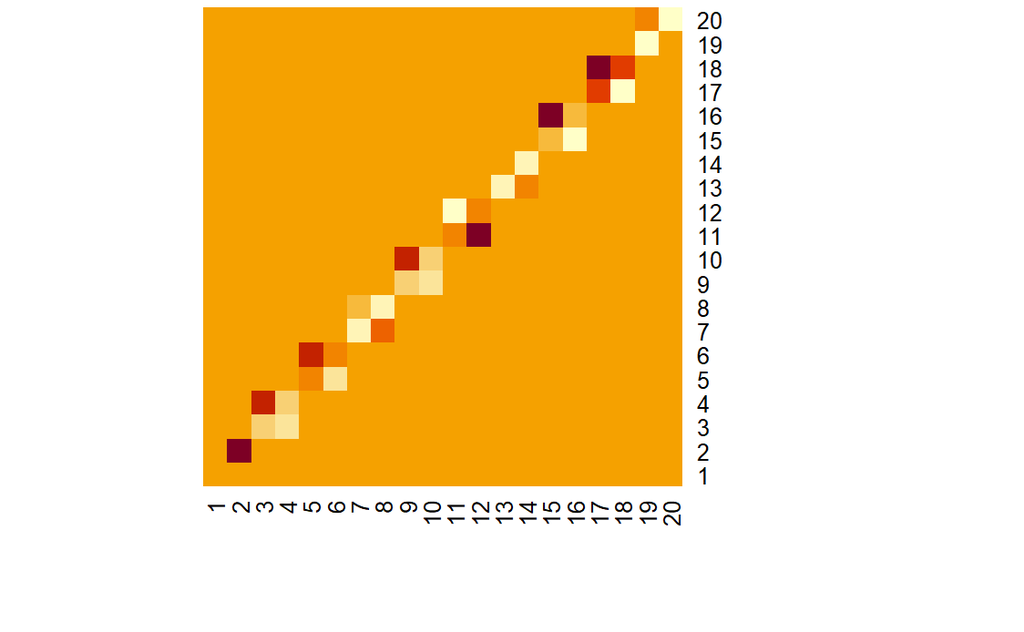

```r
mat_lambda <- stable_eigen_list[[2]]
heatmap(mat_lambda,Rowv = NA, Colv = NA, scale = "none")
```

And the generated eigenvalues are located in the unit circle.

```r
par(pin = c(3,2))
plot(
  NA, NA,
  xlim = c(-1.2, 1.2), ylim = c(-1.2, 1.2),
  xlab = "Real Part", ylab = "Imaginary Part",
  main = "Eigenvalue Distribution",
  asp = 1
)

lines(circle_ix, circle_iy, col = "black", lty = 2)
```

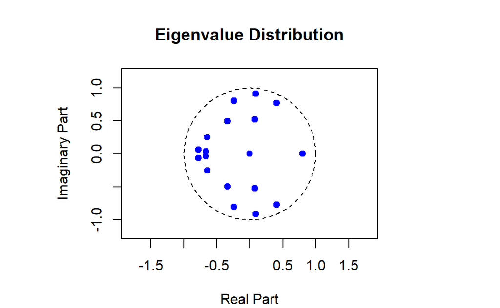

```r
points(eigen_values, pch = 19, col = "blue")
```

The overall distribution is slightly different from random matrices. Especially, generated complex eigenvalues distributed exactly randomly, even around the real axis.

```r
n<-20
m<-1000
real_eigen<-rep(0,m)

rad_i <- 1
theta <- seq(0, 2*pi, length.out = 200)
circle_ix <- rad_i*cos(theta)
circle_iy <- rad_i*sin(theta)

par(pin = c(4,3))
plot(
  NA, NA,
  xlim = c(-1.2, 1.2), ylim = c(-1.2, 1.2),
  xlab = "Real Part", ylab = "Imaginary Part",
  #main = "Eigenvalue Distribution",
  asp = 1
)

for (i in 1:m) {
  generated_eigen <- sample_stable_eigen(size, real_probs, const_eigen)

  eigen_valuesi <- generated_eigen[[1]]
  points(eigen_valuesi, pch = 19, col = rgb(0.5,0.5,0.5,0.1), cex = 0.5)
}
```

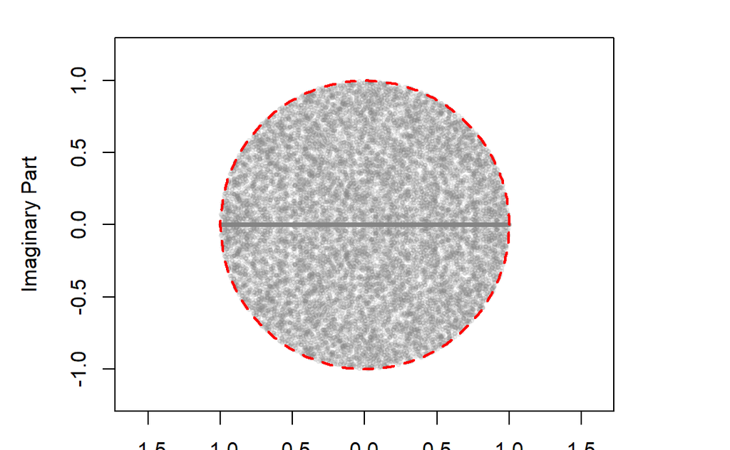

```r
lines(circle_ix, circle_iy, col = "red", lty = 2, lwd = 2)
```

## Eigenvectors

To make it easier to conpute the reverse, as well as keep the elements of generated matrix in control (see later), we choose orthogonal matrix as eigenvector matrix (with a constant column).

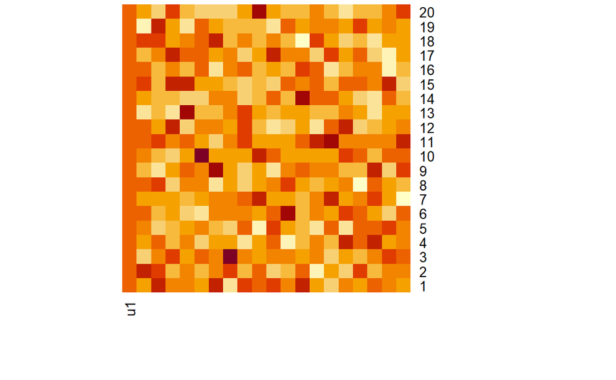

```r
generate_orth_ones <- function(n) {

  u1 <- rep(1, n) / sqrt(n)

  M <- matrix(rnorm(n * (n - 1)), n, n - 1)

  for (j in 1:(n - 1)) {
    v <- M[, j]
    v <- v - sum(v * u1) * u1
    if (j > 1) {
      for (k in 1:(j - 1)) {
        uk <- M[, k]
        v <- v - sum(v * uk) * uk
      }
    }
    M[, j] <- v / sqrt(sum(v^2))
  }

  U <- cbind(u1, M)
  return(U)
}

ortho_mat<-generate_orth_ones(20)
heatmap(ortho_mat,Rowv = NA, Colv = NA, scale = "none")
```

We will also see that such an orthogonal matrix has a very good property: $\mathbf{U}^{T} = \mathbf{U}^{-1}$.

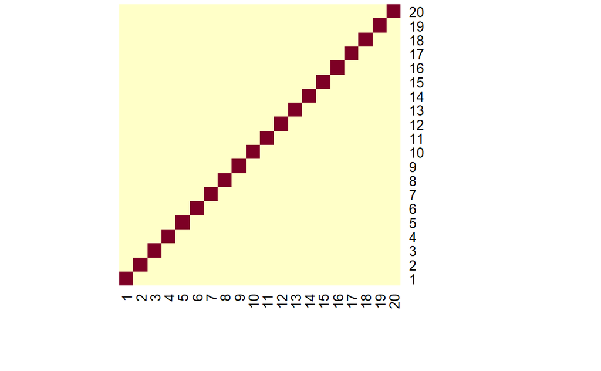

```r
heatmap(ortho_mat%*%t(ortho_mat),Rowv = NA, Colv = NA, scale = "none")
```

We are now able to generate a matrix with the conditions mentioned above.

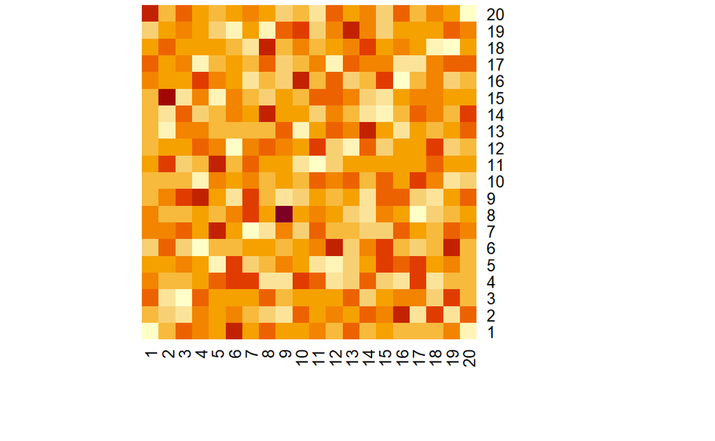

```r
generated_mat <- ortho_mat%*%mat_lambda%*%t(ortho_mat)
heatmap(generated_mat,Rowv = NA, Colv = NA, scale = "none")
```

We would also like to reorder it randomly.

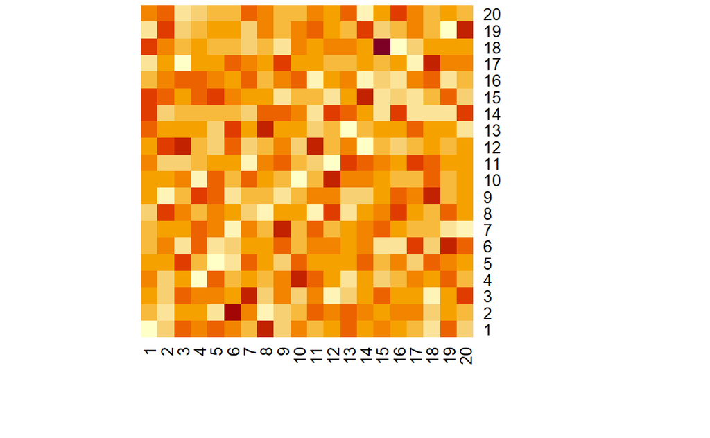

```r
random_permute_matrix <- function(A) {
  n <- nrow(A)

  perm <- sample(1:n)

  P <- diag(n)[perm, ]

  B <- P %*% A %*% t(P)

  return(B)
}
generated_random_mat <- random_permute_matrix(generated_mat)
heatmap(generated_random_mat,Rowv = NA, Colv = NA, scale = "none")
```

# Compare different matrices

We compare the following four matrices:

- random matrix
- orthogonal matrix
- generated matrix with random matrix as its eigenvector matrix
- generated matrix above

```r
rand_mat<- random_matrix(20)
rand_mat_inv <- solve(rand_mat)
```

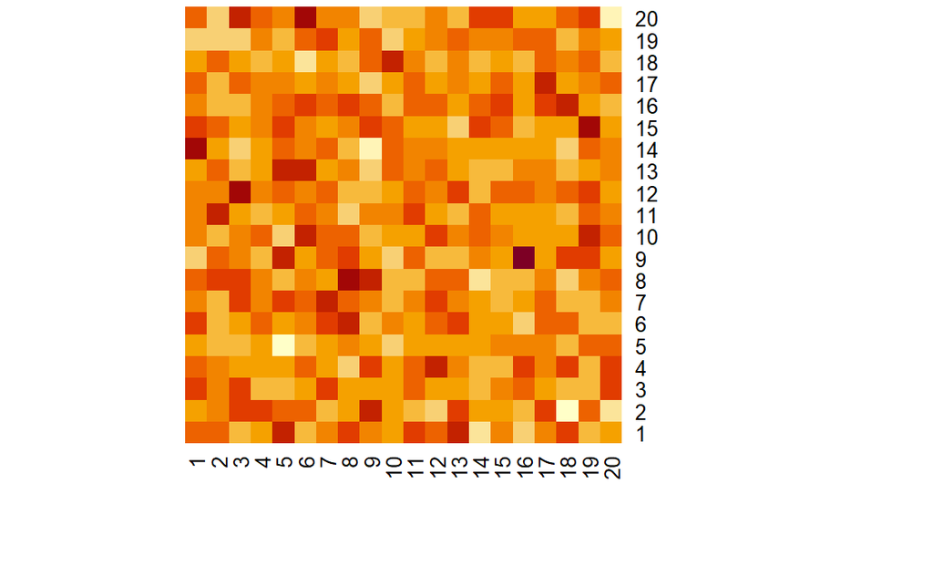

```r
par(pin = c(1,1), mfrow = c(1,4))

heatmap(rand_mat,Rowv = NA, Colv = NA, scale = "none")
```

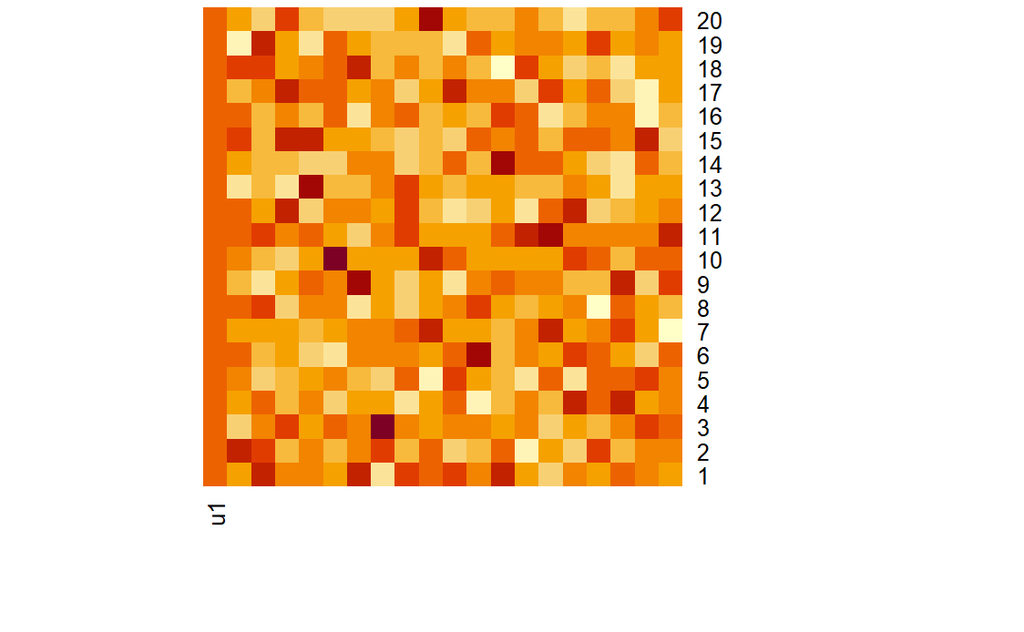

```r
heatmap(ortho_mat,Rowv = NA, Colv = NA, scale = "none")
```

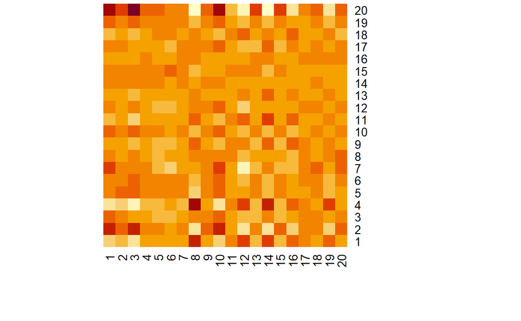

```r
heatmap(rand_mat%*%mat_lambda%*%rand_mat_inv,Rowv = NA, Colv = NA, scale = "none")
```

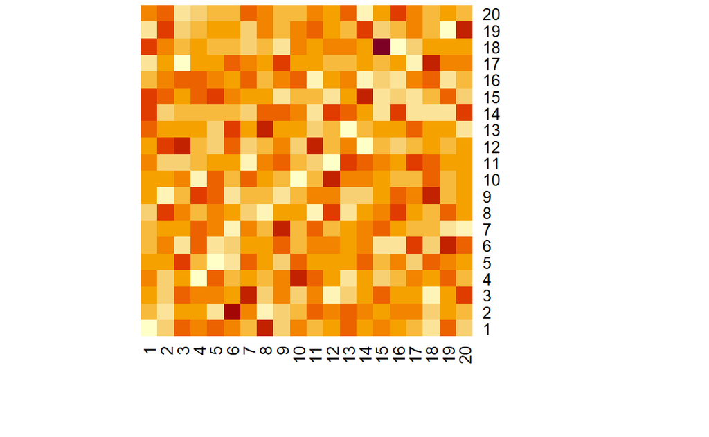

```r
heatmap(generated_random_mat,Rowv = NA, Colv = NA, scale = "none")
```

```r
par(mfrow = c(1,4), pin = c(1,1))

image(t(rand_mat[nrow(rand_mat):1, ]), col = heat.colors(20), axes = FALSE)
image(t(ortho_mat[nrow(ortho_mat):1, ]), col = heat.colors(20), axes = FALSE)
```

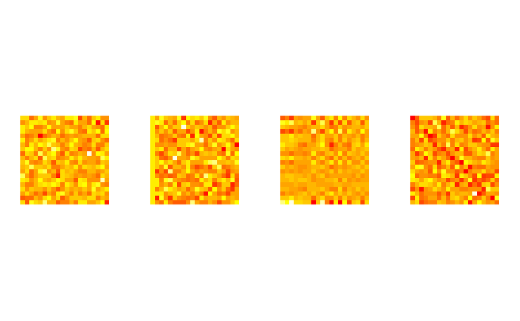

```r
image(t((rand_mat %*% mat_lambda %*% rand_mat_inv)[nrow(rand_mat):1, ]),
      col = heat.colors(20), axes = FALSE)
image(t(generated_random_mat[nrow(generated_random_mat):1, ]),
      col = heat.colors(20), axes = FALSE)
```

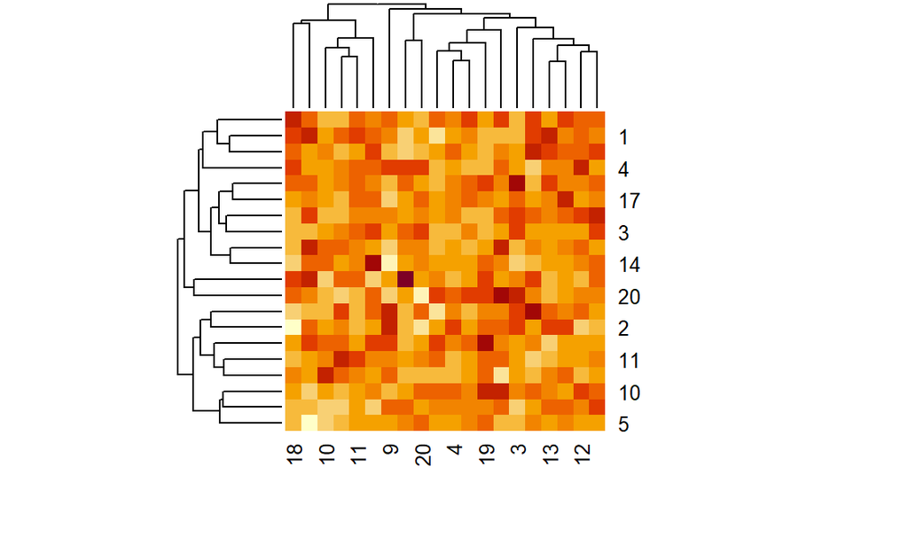

```r
heatmap(rand_mat,scale = "none")
```

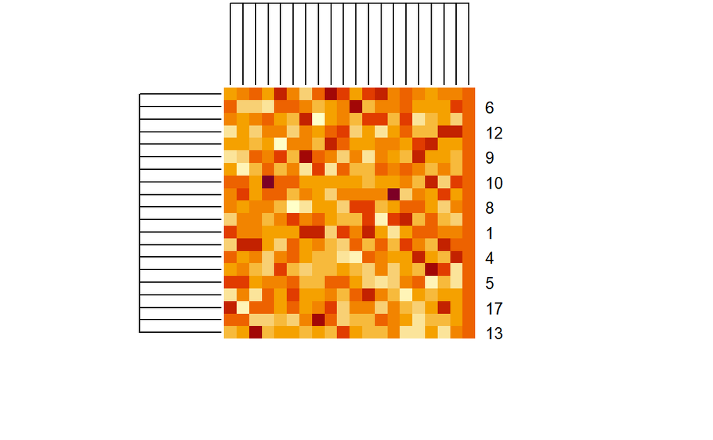

```r
heatmap(ortho_mat,scale = "none")
```

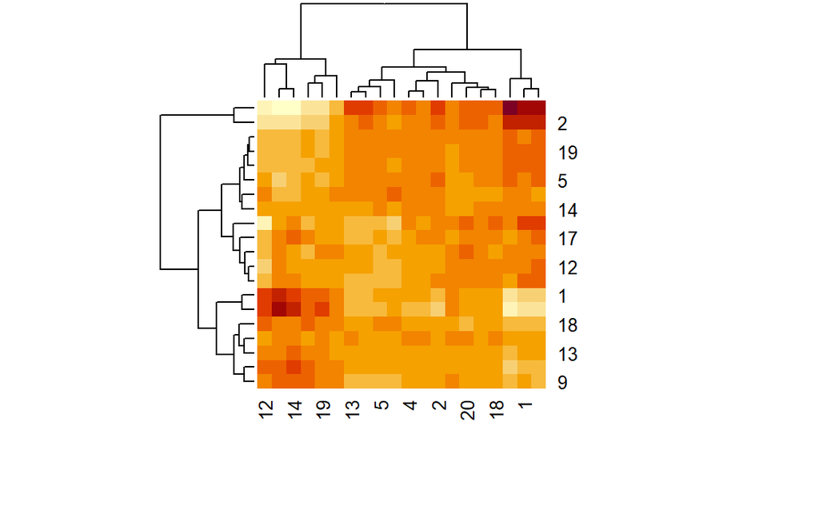

```r
heatmap(rand_mat%*%mat_lambda%*%rand_mat_inv, scale = "none")
```

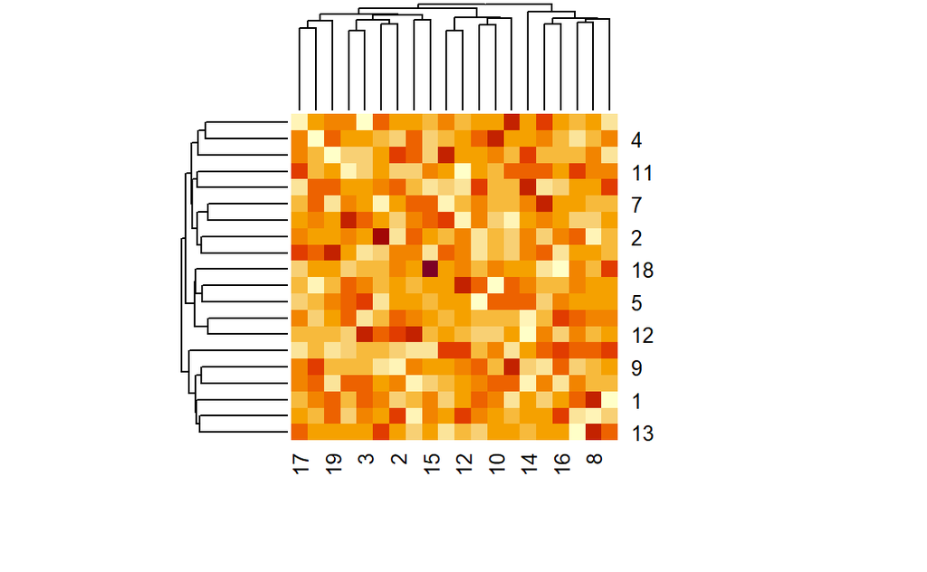

```r
heatmap(generated_random_mat,scale = "none")
```

# Generate Stable Topos

Now we can generate initial stable networks. The code used to generate the initial population is as below. Also see `generate_stable_topo.R`.

```r
## Functions ##
### Generate Stable Topos by Sampling Eigenvalues ###

## functions ##

# generate random matrix
random_matrix <- function(size,
                          dist_fun = rnorm, ...
                          #symmetric = FALSE
                                   ){
  mat <- matrix(dist_fun(size * size, ...), nrow = size, ncol = size)
  #if (symmetric) {
  #  mat <- (mat + t(mat)) / 2
  #}
  return(mat)
}

# sample stable eigenvalues (modulus smaller than 1)
# and generate the diaganol matrix
sample_stable_eigen <- function(size,
                                real_probs,
                                const_eigen) {
  mat <- matrix(0, size, size)

  # real eigenvalues
  n_real <- 0
  while (n_real == 0) {
    n_real <- sample(seq(from = size %% 2, to = size, by = 2),
                     size = 1, prob = real_probs)
  }
  mat[1, 1] <- const_eigen
  for(i in 2:n_real) {
    mat[i, i] <- runif(1, min = -1, max = 1)
  }

  # complex eigenvalues (conjugated)
  for (i in seq((n_real+1) , size , by=2)) {
    r <- sqrt(runif(1))
    theta <- runif(1, 0, 2*pi)
    a <- r * cos(theta)
    w <- r * sin(theta)
    mat[i:(i+1), i:(i+1)] <- matrix(c(a, -w, w, a), 2, 2)
  }
  return(mat)
}

# generate orthogonal matrix with an all-ones column
generate_orth_ones <- function(n) {
  u1 <- rep(1, n) / sqrt(n)
  M <- matrix(rnorm(n * (n - 1)), n, n - 1)
  for (j in 1:(n - 1)) {
    v <- M[, j]
    v <- v - sum(v * u1) * u1
    if (j > 1) {
      for (k in 1:(j - 1)) {
        uk <- M[, k]
        v <- v - sum(v * uk) * uk
      }
    }
    M[, j] <- v / sqrt(sum(v^2))
  }
  U <- cbind(u1, M)
  return(U)
}

# permute columns and rows
random_permute_matrix <- function(A) {
  n <- nrow(A)
  perm <- sample(1:n)
  P <- diag(n)[perm, ]
  B <- P %*% A %*% t(P)
  return(B)
}

# generate stable matrix

matrix_generator<- function(size,
                            real_probs,
                            const_eigen){
  Lambda <- sample_stable_eigen(size, real_probs, const_eigen)
  V <- generate_orth_ones(size)
  mat <- random_permute_matrix(V%*%Lambda%*%t(V))

  return(mat)
}
```

```r
## MAIN ##
size <- 20
set.seed(33550336)

#sample the distribution of real eigenvalues
m<-10000
real_eigen<-rep(0,m)
for (i in 1:m) {
  mat<- random_matrix(size)
  real_eigen[i] <- sum(Im(eigen(mat)$values)==0)
}
possible_vals <- seq(from = size %% 2, to = size, by = 2)
real_num_freq <- table(factor(real_eigen, levels = possible_vals))
real_probs<-as.vector(real_num_freq/m)

#generate
if(!dir.exists("generated_stable_topos")){
  dir.create("generated_stable_topos")
}
setwd("generated_stable_topos")

fit_expression <- 0.5
basal_expression <- 0.5
const_eigen <- 1 - basal_expression/fit_expression

n_net <- 1000
n_pop <- 100

for (p in 1:n_pop) {
  sub_dir <- paste0("population_", p, "_", n_net)
  if (!dir.exists(sub_dir)) {
    dir.create(sub_dir)
  }

  for (i in 1:n_net) {
    mat <- matrix_generator(size, real_probs, const_eigen)
    file_name <- paste0("ind_net_", p, "_", i, ".txt")
    file_path <- file.path(sub_dir, file_name)
    write.table(mat, file = file_path, sep = " ", row.names = FALSE, col.names = FALSE, quote = FALSE)
  }
}

n_net <- 10000
n_pop <- 10

for (p in 1:n_pop) {
  sub_dir <- paste0("population_", p, "_", n_net)
  if (!dir.exists(sub_dir)) {
    dir.create(sub_dir)
  }

  for (i in 1:n_net) {
    mat <- matrix_generator(size, real_probs, const_eigen)
    file_name <- paste0("ind_net_", p, "_", i, ".txt")
    file_path <- file.path(sub_dir, file_name)
    write.table(mat, file = file_path, sep = " ", row.names = FALSE, col.names = FALSE, quote = FALSE)
  }
}
```

# Properties of Generated Matrix

Here we are going to compare generated matrices with random matrices in more detail. For random matrices, most of the results are obvious. We generate $1000$ matrices to compare with random ones.

```r
matrices_generator<- function(N_net, size, seed = 123){
  networks <- list()
  set.seed(seed)

  while (length(networks) < N_net) {
    mat <- matrix_generator(size,
                            real_probs,
                            const_eigen)
    networks[[length(networks) + 1]] <- mat
  }
  return(networks)
}
networks <- matrices_generator(1000,size)
```

Then we take all of the elements, to show the distribution of elements.

```r
all_vals <- unlist(lapply(networks, function(mat) as.vector(mat)))
all_vals_n_diag <- unlist(lapply(networks, function(mat) mat[!diag(nrow(mat))]))

all_vals <- all_vals[!is.na(all_vals)]
df_vals <- data.frame(value = all_vals)
```

Here we calculate some basic statistics.

```r
n <- length(all_vals)
xbar <- mean(all_vals)
s <- sd(all_vals)
SE = s/sqrt(n)
skew <- if(requireNamespace("moments", quietly = TRUE)) moments::skewness(all_vals) else sum((all_vals - xbar)^3)/(n * s^3)
kurt <- if(requireNamespace("moments", quietly = TRUE)) moments::kurtosis(all_vals) else sum((all_vals - xbar)^4)/(n * s^4) - 3

cat("n =", n, "\n")
```

```
n = 400000
```

```r
cat("mean =", xbar, "\n")
```

```
mean = -1.417361e-20
```

```r
cat("sd =", s, "\n")
```

```
sd = 0.1500445
```

```r
cat("SE =", SE, "\n")
```

```
SE = 0.0002372412
```

```r
cat("skewness =", skew, "\n")
```

```
skewness = 0.0132493
```

```r
cat("excess kurtosis =", kurt, "\n\n")
```

```
excess kurtosis = 3.041709
```

## Normality

We draw the distribution of all elements, and show the kernel density as well as a normal distribution with the same mean and standard deviation.

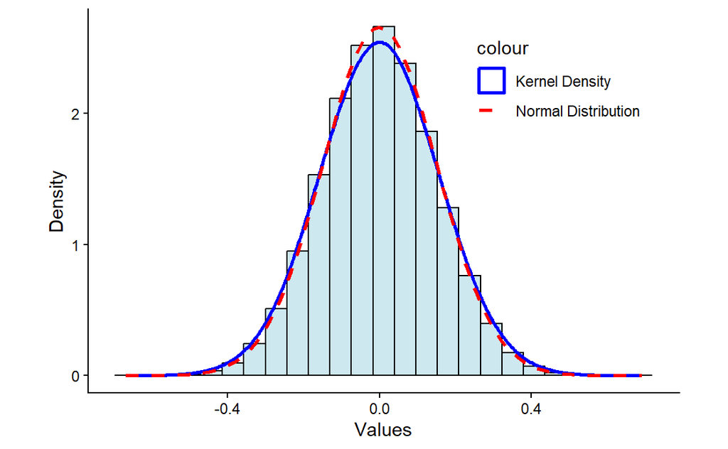

```r
p_hist <- ggplot(df_vals, aes(x = value)) +
  # Histogram
  geom_histogram(aes(y = ..density..),
                 bins = 25,
                 fill = "lightblue",
                 color = "black",
                 alpha = 0.6) +
  scale_color_manual(values = c("Kernel Density" = "blue",
                                "Normal Distribution" = "red"))+
  #kernel density
  geom_density(aes(color = "Kernel Density"),
               linewidth = 1,
               bw = 0.047) +

  # Theoretical Normal distribution curve
  stat_function(fun = dnorm,
                args = list(mean = xbar, sd = s),
                aes(color = "Normal Distribution"),
                linewidth = 1,
                linetype = "dashed") +

  #ggtitle("Distribution of elements") +
  theme_classic() +
  labs(x = "Values", y = "Density")+
  theme(
    legend.position = c(0.95, 0.95),
    legend.justification = c("right", "top"), legend.key = element_blank(),
    legend.background = element_rect(fill = alpha('white', 0.6), color = NA),
    aspect.ratio = 0.65
  )

p_hist
```

And QQ plot

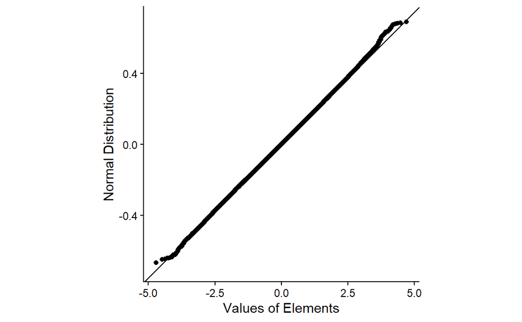

```r
# ---- QQ 图 ----
p_qq <- ggplot(df_vals, aes(sample = value)) +
  stat_qq() +
  stat_qq_line() +
  labs(x = "Values of Elements", y = "Normal Distribution")+
  theme_classic()+
  theme(aspect.ratio = 1)
p_qq
```

Also, we could test the normality.

```r
# ---- Normality Test ----
  ad <- nortest::ad.test(all_vals)        # Anderson-Darling
  lillie <- nortest::lillie.test(all_vals) # Lilliefors / Kolmogorov–Smirnov verify
  cat("Anderson-Darling:\n"); print(ad)
```

```
Anderson-Darling:

    Anderson-Darling normality test

data:  all_vals
A = 1.8755, p-value = 8.715e-05
```

```r
  cat("\nLilliefors (nortest::lillie.test):\n"); print(lillie)
```

```
Lilliefors (nortest::lillie.test):

    Lilliefors (Kolmogorov-Smirnov) normality test

data:  all_vals
D = 0.0018709, p-value = 0.005254
```

```r
  # randomly sample 5000 spot to do Shapiro
  set.seed(123)
  sample_for_shapiro <- sample(all_vals, size = min(5000, n))
  cat("\n For a random sample (size = ", length(sample_for_shapiro), ")  Shapiro-Wilk ：\n", sep = "")
```

```
 For a random sample (size = 5000)  Shapiro-Wilk ：
```

```r
  print(shapiro.test(sample_for_shapiro))
```

```
    Shapiro-Wilk normality test

data:  sample_for_shapiro
W = 0.99969, p-value = 0.6883
```

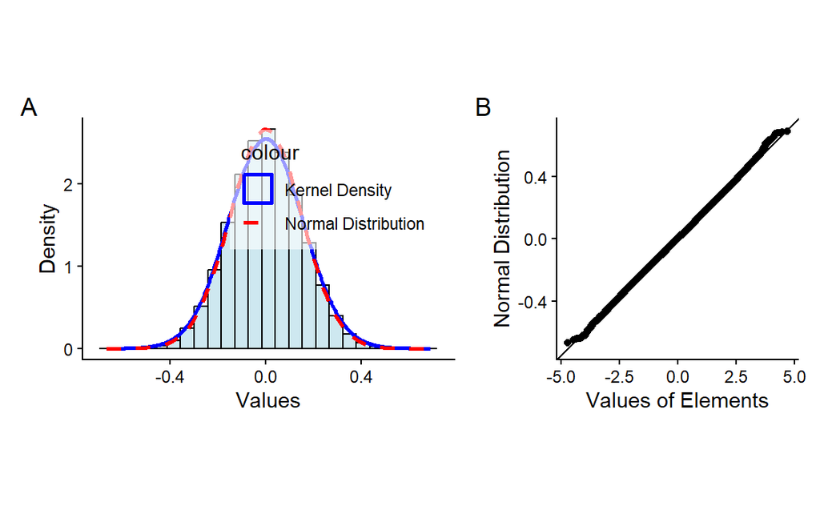

```r
p1 <- p_hist +
  theme_classic() +
  theme(
    legend.position = c(0.95, 0.95),
    legend.justification = c("right", "top"),
    legend.key = element_blank(),
    legend.background = element_rect(
      fill = alpha("white", 0.6),
      color = NA
    ),
    aspect.ratio = 0.65
  )

p2 <- p_qq +
  theme_classic() +
  theme(aspect.ratio = 1)

combined_plot <- (p1 | p2) +
  plot_layout(guides = "keep") +
  plot_annotation(tag_levels = "A")

combined_plot
```

```r
#ggsave("elements_dist.png", width = 12, height = 5, dpi = 300)
```

## Asymmetry and Row correlation

```r
# Asymmetry Function
asymmetry <- function(mat) {
  norm(mat - t(mat), type="F") / norm(mat, type="F")
}

set.seed(33550336)

n_matrix <- length(networks)


genmat_corr <- numeric(n_matrix)
rand_corr <- numeric(n_matrix)
genmat_asym <- numeric(n_matrix)
rand_asym <- numeric(n_matrix)

for(i in seq_along(networks)){
  mati <- networks[[i]]
  row_cor <- cor(t(mati))
  genmat_corr[i] <- mean(abs(row_cor[upper.tri(row_cor)]))
  genmat_asym[i] <- asymmetry(mati)
}

for(j in 1:n_matrix){
  rand_mat <- matrix(rnorm(20*20, mean=xbar, sd=s),
                       nrow= 20)
  rand_cor <- cor(t(rand_mat))
  rand_corr[j] <- mean(abs(rand_cor[upper.tri(rand_cor)]))
  rand_asym[j] <- asymmetry(rand_mat)
}
```

Correlation:

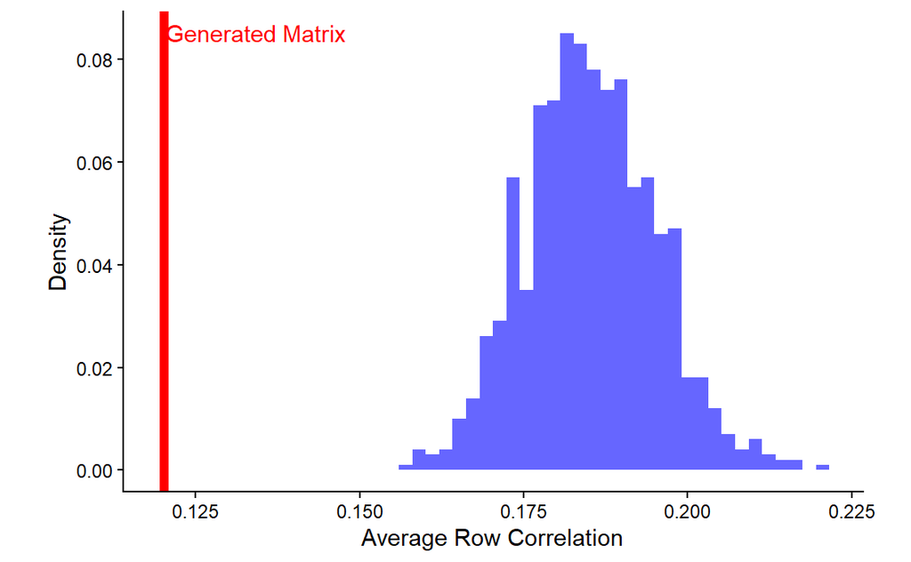

```r
genmat_value <- mean(genmat_corr)

p_corr<-ggplot(data.frame(value = rand_corr), aes(x = value)) +
  geom_histogram(aes(y = after_stat(count / sum(count))),
                 bins = 50, fill = "blue", alpha = 0.6) +
  geom_vline(xintercept = genmat_value, color = "red", linewidth = 2) +
  annotate("text", x = genmat_value+0.014, y = 0.08, label = "Generated Matrix", color = "red", vjust = -1) +
  xlab("Average Row Correlation") +
  ylab("Density") +
  theme_classic() +
  theme(aspect.ratio = 0.65)

p_corr
```

Asymmetry

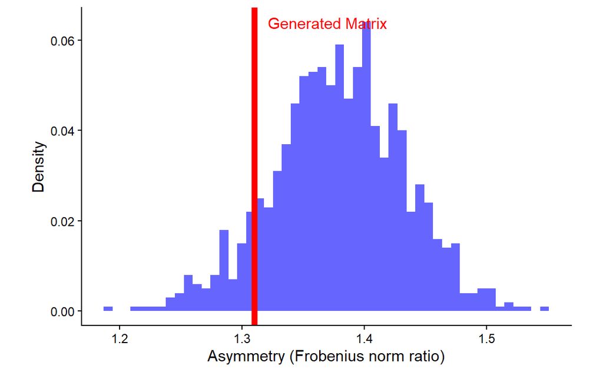

```r
genmat_value_asym <- mean(genmat_asym)

p_asym<-ggplot(data.frame(value = rand_asym), aes(x = value)) +
  geom_histogram(aes(y = after_stat(count / sum(count))),
                 bins = 50, fill = "blue", alpha = 0.6) +
  geom_vline(xintercept = genmat_value_asym, color = "red", linewidth = 2) +
  annotate("text", x = genmat_value_asym+0.06, y = 0.06, label = "Generated Matrix", color = "red", vjust = -1) +
  xlab("Asymmetry (Frobenius norm ratio)")+
  ylab("Density") +
  theme_classic() +
  theme(aspect.ratio = 0.65)

p_asym
```

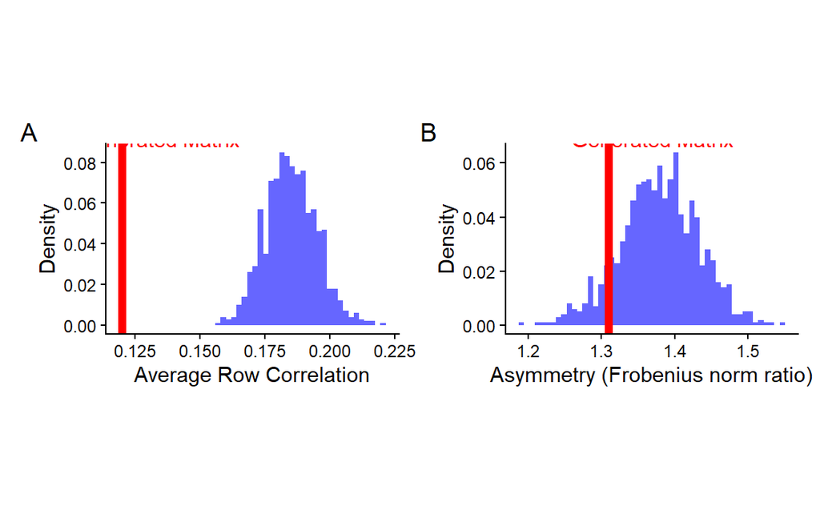

```r
p1 <- p_cor
p2 <- p_asym

combined_plot_stat <- ((p1) +(p2))+
  plot_layout(guides = "collect") +
  plot_annotation(tag_levels = 'A')

combined_plot_stat
```

```r
#ggsave("mat_rand_comp.png", width = 12, height = 5, dpi = 300)
```

# Simple Simulation of the Dynamic

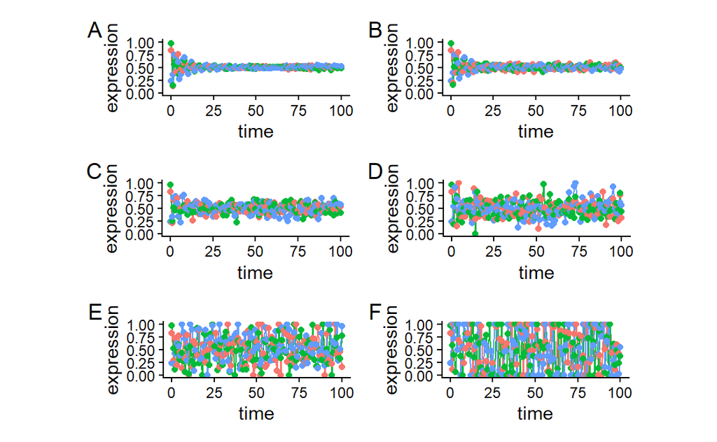

```r
#sigma function
func_cut <- function(x) {
  x[x > 1] <- 1
  x[x < 0] <- 0
  return(x)
}

# simulation and plot
simulate_plot <- function(x0, W, b, sd_noise, k) {

  X <- matrix(0, nrow = n, ncol = k + 1)
  X[,1] <- x0

  for (t in 1:k) {
    X[, t + 1] <- func_cut(W %*% X[, t] + b + rnorm(n, sd = sd_noise))
  }

  df_long_subset <- as.data.frame(t(X)) |>
    dplyr::mutate(time = 0:k) |>
    tidyr::pivot_longer(-time, names_to = "node", values_to = "expression") |>
    dplyr::filter(node %in% paste0("V", 1:3))

  ggplot(df_long_subset, aes(time, expression, color = node)) +
    geom_line() +
    geom_point(size = 1.5) +
    ylim(0,1) +
    theme_classic() +
    theme(
      legend.position = "none",
      aspect.ratio = 0.3
    )
}

#parameters
n <- 20
k <- 100
b <- rep(0.5, n)
x0 <- rep(0.5, n)
x0 <- runif(n, min = 0, max = 1)
noise_levels <- c(0.01, 0.02, 0.05, 0.1, 0.2, 0.5)

plots <- lapply(noise_levels, function(sd) {
  simulate_plot(x0 = x0, W = generated_random_mat, b = basal_expression, sd_noise = sd, k = k)
})

# -------------------------
# 拼图
# -------------------------
combined_plot <-
  (plots[[1]] + plots[[2]]) /
  (plots[[3]] + plots[[4]]) /
  (plots[[5]] + plots[[6]]) +
  plot_annotation(tag_levels = "A")

combined_plot
```

```r
#ggsave("noise_expression_example.png", width = 15, height = 10, dpi = 300)
```

Without noise, the trajectory will converge to the stable state.

[figure not shown]

```r
p_nonnoise <- simulate_plot(x0 = x0, W = generated_random_mat, b = basal_expression, sd_noise = 0, k = k)
p_nonnoise
```

Former plots

```r
W <- generated_random_mat
```

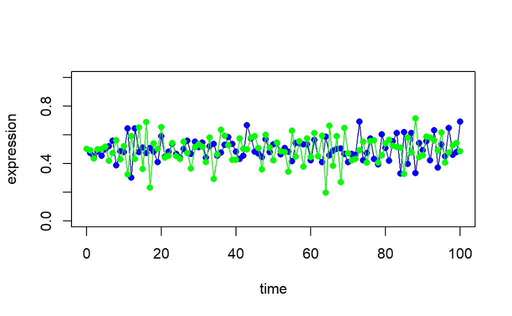

```r
n<-20
b <- rep(0.5, n)
#x0<- rnorm(20, mean = 0.5, sd = 0.2)
#y0<- rnorm(20, mean = 0.5, sd = 0.2)
x0<-rep(0.5,20)
y0<-rep(0.5,20)
k <- 100

X <- matrix(0, nrow = n, ncol = k+1)
X[,1] <- x0
Y <- matrix(0, nrow = n, ncol = k+1)
Y[,1] <- y0


for (t in 1:k) {
  X[,t+1] <- W %*% X[,t] + b + rnorm(n, sd = 0.05)
}
for (t in 1:k) {
  Y[,t+1] <- W %*% Y[,t] + b + rnorm(n, sd = 0.05)
}


plot(0:k, X[1,], type="o", pch=16, col="blue",ylim = c(0, 1), xlab = "time", ylab = "expression")
lines(0:k, Y[1,], type="o", pch=16, col="green")
```

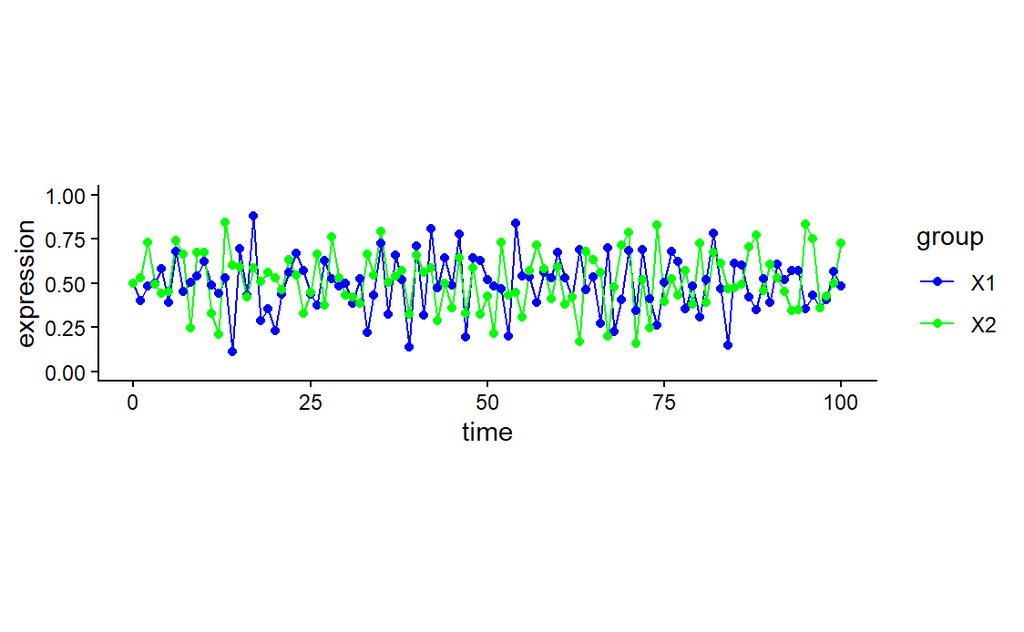

```r
n <- 20
b <- rep(0.5, n)
x0 <- rep(0.5, n)
y0 <- rep(0.5, n)
k <- 100

X <- matrix(0, nrow = n, ncol = k + 1)
Y <- matrix(0, nrow = n, ncol = k + 1)
X[, 1] <- x0
Y[, 1] <- y0

noise<-0.1

for (t in 1:k) {
  X[, t + 1] <- W %*% X[, t] + b + rnorm(n, sd = noise)
  Y[, t + 1] <- W %*% Y[, t] + b + rnorm(n, sd = noise)
}

df <- data.frame(
  time = rep(0:k, 2),
  expression = c(X[1, ], X[2, ]),
  group = rep(c("X1", "X2"), each = k + 1)
)

ggplot(df, aes(x = time, y = expression, color = group)) +
  geom_line() +
  geom_point(size = 1.5) +
  scale_color_manual(values = c("blue", "green")) +
  ylim(0, 1) +
  labs(x = "time", y = "expression") +
  theme_classic()+
  theme(aspect.ratio = 0.25)
```